# Lösungen

## Lösungen zu den Aufgaben

#### Aufgabe

1. Eine logistische Regression wurde an einen Datensatz angepasst. Es ergaben sich folgende Koeffizienten (jeweils Punktschätzer):

   `Konstante = -1.9` `x = 0.7` `z = 0.7`

   `x` ist ein metrischer Prädiktor mit einem Range von 0 bis 10; `z` ist eine binärer Prädiktor (mit den Werten 0 und 1).

   Visualisieren Sie die Kurven in einem Diagramm für
   1. $\mathcal{L}$ vs. $x$
   2. $Pr(y=1)$ vs. $x$

#### Lösung

   Wir definieren die Variablen:

   ```
   d <-
     tibble(
       x = seq(from = 0, to = 10, by = 0.1),
       z = 1,
       y_z0_linear = -1.9 + 0.7 * x + 0*z,
       y_z1_linear = -1.9 + 0.7 * x + 1*z,
       p_y_z0 = plogis(y_z0_linear),
       p_y_z1 = plogis(y_z1_linear)
     )
   ```

   Hier ist das Diagramm mit *Logits* auf der Y-Achse:

   ```
   d %>%
     ggplot() +
     aes(x = x) +
     geom_line(aes(y = y_z0_linear), color = "blue") +
     geom_line(aes(y = y_z1_linear), color = "red")
   ```

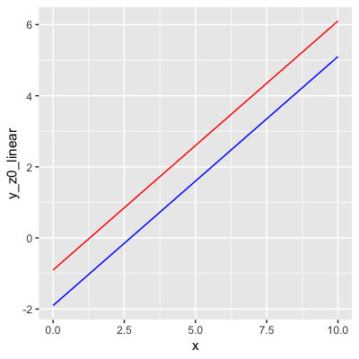

   Hier ist das Diagramm mit *Wahrscheinlichkeit* auf der Y-Achse:

   ```
   d %>%
     ggplot() +
     aes(x = x) +
     geom_line(aes(y = p_y_z0), color = "blue") +
     geom_line(aes(y = p_y_z1), color = "red")
   ```

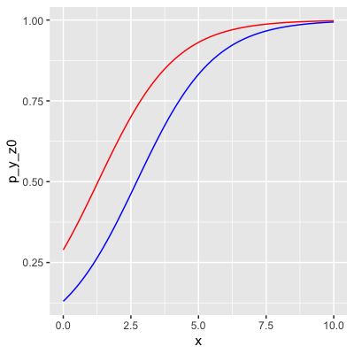

#### Aufgabe

2. *Forschungsfrage*: Ist der Zusammenhang von Körpergröße und ‘Mann’ positiv? Gehen also höhere Werte in Körpergröße `height` einher mit einer höheren Wahrscheinlichkeit, dass es sich um einen Mann `male` handelt?

## Vorbereitung

   ```
   library(tidymodels)
   library(tidyverse)
   library(tictoc)  # Zeitmessung der Rechenzeit
   ```

   ```
   d <- read_csv(
   "https://vincentarelbundock.github.io/Rdatasets/csv/openintro/speed_gender_height.csv")
   ```

   ```
   ## ───────────────────── Delimiter: "," chr
   ## (1): gender dbl (3): ...1, speed, height
   ## specification for this data. ℹ Specify the
   ## column types or set `show_col_types = FALSE`
   ## to quiet this message.
   ```

   Bereiten wir die Daten vor:

## Datenaufteilung

   Es ist praktisch, die AV vorab in einen Faktor umzuwandeln (s. weiter unten):

   ```
   d <-
     d %>%
     mutate(gender = factor(gender))
   ```

   Zur Erinnerung: `tidymodels` modelliert die *erste Stufe* der AV:

   ```
   levels(d$gender)
   ```

   ```
   ## [1] "female" "male"
   ```

   Also lieber re-leveln:

   ```
   d <-
     d %>%
     mutate(gender = relevel(gender, ref = "male"))


   levels(d$gender)  # check
   ```

   ```
   ## [1] "male"   "female"
   ```

   Dann kommt die initial Datenaufteilung:

   ```
   d_split <- initial_split(d, strata = "gender")
   d_train <- training(d_split)
   d_test <- testing(d_split)
   ```

## Modelldefinition

   ```
   logist_mod <-
     logistic_reg()

   rsmpling <- vfold_cv(d_train, strata = "gender", repeats = 5)

   recipe1 <- recipe(gender ~ height, data = d_train)  %>%
     step_mutate(height = height * 2.54) %>%
     step_impute_knn()

   wf1 <-
     workflow() %>%
     add_model(logist_mod) %>%
     add_recipe(recipe1)
   ```

## Modell fitten

   ```
   tic()  # Stoppuhr an
   fit1 <-
     fit_resamples(wf1,
                   rsmpling,
                   metrics = metric_set(roc_auc, sens, spec, ppv)
     )
   toc()  # Stoppuhr aus
   ```

   ```
   ## 16.358 sec elapsed
   ```

   ```
   fit1
   ```

   ```
   ## # Resampling results
   ## # 10-fold cross-validation repeated 5 times using stratification
   ## # A tibble: 50 × 5
   ##    splits            id      id2    .metrics
   ##    <list>            <chr>   <chr>  <list>
   ##  1 <split [892/101]> Repeat1 Fold01 <tibble>
   ##  2 <split [893/100]> Repeat1 Fold02 <tibble>
   ##  3 <split [894/99]>  Repeat1 Fold03 <tibble>
   ##  4 <split [894/99]>  Repeat1 Fold04 <tibble>
   ##  5 <split [894/99]>  Repeat1 Fold05 <tibble>
   ##  6 <split [894/99]>  Repeat1 Fold06 <tibble>
   ##  7 <split [894/99]>  Repeat1 Fold07 <tibble>
   ##  8 <split [894/99]>  Repeat1 Fold08 <tibble>
   ##  9 <split [894/99]>  Repeat1 Fold09 <tibble>
   ## 10 <split [894/99]>  Repeat1 Fold10 <tibble>
   ## # … with 40 more rows, and 1 more variable:
   ## #   .notes <list>
   ```

## Ergebnisse im Train-Sample

   ```
   collect_metrics(fit1)
   ```

   ```
   ## # A tibble: 4 × 6
   ##   .metric .estimator  mean     n std_err
   ##   <chr>   <chr>      <dbl> <int>   <dbl>
   ## 1 ppv     binary     0.808    50 0.00907
   ## 2 roc_auc binary     0.881    50 0.00443
   ## 3 sens    binary     0.650    50 0.0102
   ## 4 spec    binary     0.921    50 0.00432
   ## # … with 1 more variable: .config <chr>
   ```

   Da wir *nicht* gesagt haben, dass die Vorhersagen gespeichert werden sollen, können wir Sie uns auch nicht anschauen:

   ```
   collect_predictions(fit1)
   ```

   ```
   ## Error in `collect_predictions()`:
   ## ! The `.predictions` column does not exist. Refit with the control argument `save_pred = TRUE` to save predictions.
   ```

   Das hätten wir so machen können, also mit `control()`, dann können wir die Vorhersagen speichern:

   ```
   tic()  # Stoppuhr an
   fit2 <-
     fit_resamples(wf1,
                   rsmpling,
                   metrics = metric_set(roc_auc, sens, spec, ppv),
                   control = control_resamples(save_pred = TRUE)  # NEUE ZEILE

     )
   toc()  # Stoppuhr aus
   ```

   ```
   ## 16.726 sec elapsed
   ```

   Dauert schon ein bisschen…

   Dabei ist die logistische Regression sehr *wenig* rechenintensiv.

   ```
   fit2
   ```

   ```
   ## # Resampling results
   ## # 10-fold cross-validation repeated 5 times using stratification
   ## # A tibble: 50 × 6
   ##    splits            id      id2    .metrics
   ##    <list>            <chr>   <chr>  <list>
   ##  1 <split [892/101]> Repeat1 Fold01 <tibble>
   ##  2 <split [893/100]> Repeat1 Fold02 <tibble>
   ##  3 <split [894/99]>  Repeat1 Fold03 <tibble>
   ##  4 <split [894/99]>  Repeat1 Fold04 <tibble>
   ##  5 <split [894/99]>  Repeat1 Fold05 <tibble>
   ##  6 <split [894/99]>  Repeat1 Fold06 <tibble>
   ##  7 <split [894/99]>  Repeat1 Fold07 <tibble>
   ##  8 <split [894/99]>  Repeat1 Fold08 <tibble>
   ##  9 <split [894/99]>  Repeat1 Fold09 <tibble>
   ## 10 <split [894/99]>  Repeat1 Fold10 <tibble>
   ## # … with 40 more rows, and 2 more variables:
   ## #   .notes <list>, .predictions <list>
   ```

   ```
   collect_metrics(fit2)
   ```

   ```
   ## # A tibble: 4 × 6
   ##   .metric .estimator  mean     n std_err
   ##   <chr>   <chr>      <dbl> <int>   <dbl>
   ## 1 ppv     binary     0.808    50 0.00907
   ## 2 roc_auc binary     0.881    50 0.00443
   ## 3 sens    binary     0.650    50 0.0102
   ## 4 spec    binary     0.921    50 0.00432
   ## # … with 1 more variable: .config <chr>
   ```

## Vorhersagen im Train-Sample

   Schauen wir uns die Vorhersagen im Train-Sample, zusammengefasst über die alle Faltungen und Wiederholungen (`?collect_predictions`).

   ```
   collect_predictions(fit2, summarize = TRUE)
   ```

   ```
   ## # A tibble: 993 × 6
   ##     .row gender .config            .pred_male
   ##    <int> <fct>  <chr>                   <dbl>
   ##  1     1 female Preprocessor1_Mod…     0.589
   ##  2     2 female Preprocessor1_Mod…     0.104
   ##  3     3 female Preprocessor1_Mod…     0.0159
   ##  4     4 female Preprocessor1_Mod…     0.0253
   ##  5     5 female Preprocessor1_Mod…     0.166
   ##  6     6 female Preprocessor1_Mod…     0.161
   ##  7     7 female Preprocessor1_Mod…     0.0702
   ##  8     8 female Preprocessor1_Mod…     0.0683
   ##  9     9 female Preprocessor1_Mod…     0.161
   ## 10    10 female Preprocessor1_Mod…     0.108
   ## # … with 983 more rows, and 2 more
   ## #   variables: .pred_female <dbl>,
   ## #   .pred_class <fct>
   ```

   ROC-Kurve im Train-Sample

   ```
   roc_data <-
     fit2 %>%
     collect_predictions(summarize = TRUE) %>%
     select(.pred_male) %>%
     bind_cols(d_train) %>%
     roc_curve(truth = gender, estimate = .pred_male)
   roc_data
   ```

   ```
   ## # A tibble: 989 × 3
   ##     .threshold specificity sensitivity
   ##          <dbl>       <dbl>       <dbl>
   ##  1 -Inf            0             1
   ##  2    0.000262     0             1
   ##  3    0.000289     0             0.997
   ##  4    0.000304     0.00152       0.997
   ##  5    0.00130      0.00304       0.997
   ##  6    0.00200      0.00457       0.997
   ##  7    0.00217      0.00457       0.994
   ##  8    0.00382      0.00609       0.994
   ##  9    0.00403      0.00761       0.994
   ## 10    0.00405      0.00913       0.994
   ## # … with 979 more rows
   ```

   Plotten:

   ```
   roc_data %>%
     ggplot(aes(x = 1- specificity, sensitivity)) +
     geom_path() +
     geom_abline(lty = 3) +
     coord_equal() +
     theme_bw()
   ```

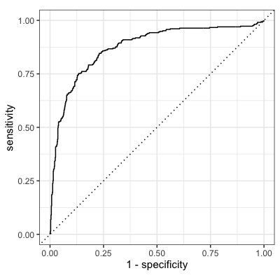

   Gar nicht schlecht!

## Vorhersagegüte im Test-Sample

   ```
   lm1_lastfit <-
     last_fit(wf1, d_split,
              metrics = metric_set(roc_auc, sens, spec, ppv)
     )

   lm1_lastfit
   ```

   ```
   ## # Resampling results
   ## # Manual resampling
   ## # A tibble: 1 × 6
   ##   splits            id      .metrics .notes
   ##   <list>            <chr>   <list>   <list>
   ## 1 <split [993/332]> train/… <tibble> <tibble>
   ## # … with 2 more variables:
   ## #   .predictions <list>, .workflow <list>
   ```

   ```
   collect_metrics(lm1_lastfit)
   ```

   ```
   ## # A tibble: 4 × 4
   ##   .metric .estimator .estimate .config
   ##   <chr>   <chr>          <dbl> <chr>
   ## 1 sens    binary         0.721 Preprocessor1…
   ## 2 spec    binary         0.937 Preprocessor1…
   ## 3 ppv     binary         0.851 Preprocessor1…
   ## 4 roc_auc binary         0.909 Preprocessor1…
   ```

   ```
   collect_predictions(lm1_lastfit)
   ```

   ```
   ## # A tibble: 332 × 7
   ##    id           .pred_male .pred_female  .row
   ##    <chr>             <dbl>        <dbl> <int>
   ##  1 train/test …     0.0261        0.974     9
   ##  2 train/test …     0.0673        0.933    37
   ##  3 train/test …     0.344         0.656    45
   ##  4 train/test …     0.0261        0.974    47
   ##  5 train/test …     0.698         0.302    49
   ##  6 train/test …     0.106         0.894    51
   ##  7 train/test …     0.242         0.758    52
   ##  8 train/test …     0.698         0.302    55
   ##  9 train/test …     0.0421        0.958    56
   ## 10 train/test …     0.106         0.894    58
   ## # … with 322 more rows, and 3 more
   ## #   variables: .pred_class <fct>,
   ## #   gender <fct>, .config <chr>
   ```

## ROC-Kurve

   ```
   lm1_lastfit %>%
     collect_predictions() %>%
     roc_curve(truth = gender, estimate = .pred_male) %>%
     ggplot(aes(x = 1 - specificity, sensitivity )) +
     geom_path() +
     geom_abline(lty = 3) +
     coord_equal() +
     theme_bw()
   ```

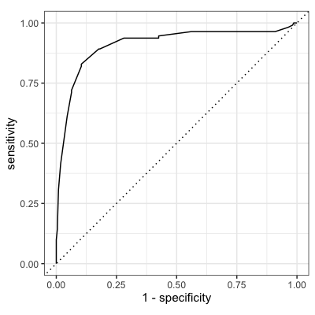

## Shinymodels

   Mit (dem R-Paket) `{{shinymodels}}` kann man sich eine App ausgeben lassen, zur Erkundung der Modellergebnisse:

   ```
   library(shinymodels)

   explore(fit2)
   ```